# Homework 5

Jake Close & Peter Kaplan

10/26/2017

First lets read in the dataset and observe the structure.

```r
library(dummies)
library(class)
library(gmodels)
#the data is split by semi colon, not a comma.
tele <- read.csv("telemarketing.csv", sep = ";")
str(tele)
```

```
## 'data.frame':    41188 obs. of  21 variables:
##  $ age           : int  56 57 37 40 56 45 59 41 24 25 ...
##  $ job           : Factor w/ 12 levels "admin.","blue-collar",..: 4 8 8 1 8 8 1 2 10 8 ...
##  $ marital       : Factor w/ 4 levels "divorced","married",..: 2 2 2 2 2 2 2 2 3 3 ...
##  $ education     : Factor w/ 8 levels "basic.4y","basic.6y",..: 1 4 4 2 4 3 6 8 6 4 ...
##  $ default       : Factor w/ 3 levels "no","unknown",..: 1 2 1 1 1 2 1 2 1 1 ...
##  $ housing       : Factor w/ 3 levels "no","unknown",..: 1 1 3 1 1 1 1 1 3 3 ...
##  $ loan          : Factor w/ 3 levels "no","unknown",..: 1 1 1 1 3 1 1 1 1 1 ...
##  $ contact       : Factor w/ 2 levels "cellular","telephone": 2 2 2 2 2 2 2 2 2 2 ...
##  $ month         : Factor w/ 10 levels "apr","aug","dec",..: 7 7 7 7 7 7 7 7 7 7 ...
##  $ day_of_week   : Factor w/ 5 levels "fri","mon","thu",..: 2 2 2 2 2 2 2 2 2 2 ...
##  $ duration      : int  261 149 226 151 307 198 139 217 380 50 ...
##  $ campaign      : int  1 1 1 1 1 1 1 1 1 1 ...
##  $ pdays         : int  999 999 999 999 999 999 999 999 999 999 ...
##  $ previous      : int  0 0 0 0 0 0 0 0 0 0 ...
##  $ poutcome      : Factor w/ 3 levels "failure","nonexistent",..: 2 2 2 2 2 2 2 2 2 2 ...
##  $ emp.var.rate  : num  1.1 1.1 1.1 1.1 1.1 1.1 1.1 1.1 1.1 1.1 ...
##  $ cons.price.idx: num  94 94 94 94 94 ...
##  $ cons.conf.idx : num  -36.4 -36.4 -36.4 -36.4 -36.4 -36.4 -36.4 -36.4 -36.4 -36.4 ...
##  $ euribor3m     : num  4.86 4.86 4.86 4.86 4.86 ...
##  $ nr.employed   : num  5191 5191 5191 5191 5191 ...
##  $ y             : Factor w/ 2 levels "no","yes": 1 1 1 1 1 1 1 1 1 1 ...
```

Also, lets observe the current proportion of our target value: has the client subscribed a term deposit?

```r
round(prop.table(table(tele$y)) * 100, 1)
```

```
##
##   no  yes
## 88.7 11.3
```

We see that there is a base of 88.7 % people saying no. Therefore, our model should be atleast this accurate in order to be useful.

Lets find out which variables have missing data and see if we can account for that.

```r
colSums(is.na(tele))
```

```
##            age            job        marital      education        default
##              0              0              0              0              0
##        housing           loan        contact          month    day_of_week
##              0              0              0              0              0
##       duration       campaign          pdays       previous       poutcome
##              0              0              0              0              0
##   emp.var.rate cons.price.idx  cons.conf.idx      euribor3m    nr.employed
##              0              0              0              0              0
##              y
##              0
```

We find there are no missing data.

Lets explore the general statistics of the data.

```r
summary(tele)
```

```
##       age                 job            marital
##  Min.   :17.00   admin.     :10422   divorced: 4612
##  1st Qu.:32.00   blue-collar: 9254   married :24928
##  Median :38.00   technician : 6743   single  :11568
##  Mean   :40.02   services   : 3969   unknown :   80
##  3rd Qu.:47.00   management : 2924
##  Max.   :98.00   retired    : 1720
##                  (Other)    : 6156
##                education        default         housing
##  university.degree  :12168   no     :32588   no     :18622
##  high.school        : 9515   unknown: 8597   unknown:  990
##  basic.9y           : 6045   yes    :    3   yes    :21576
##  professional.course: 5243
##  basic.4y           : 4176
##  basic.6y           : 2292
##  (Other)            : 1749
##       loan            contact          month       day_of_week
##  no     :33950   cellular :26144   may    :13769   fri:7827
##  unknown:  990   telephone:15044   jul    : 7174   mon:8514
##  yes    : 6248                     aug    : 6178   thu:8623
##                                    jun    : 5318   tue:8090
##                                    nov    : 4101   wed:8134
##                                    apr    : 2632
##                                    (Other): 2016
##     duration         campaign          pdays          previous
##  Min.   :   0.0   Min.   : 1.000   Min.   :  0.0   Min.   :0.000
##  1st Qu.: 102.0   1st Qu.: 1.000   1st Qu.:999.0   1st Qu.:0.000
##  Median : 180.0   Median : 2.000   Median :999.0   Median :0.000
##  Mean   : 258.3   Mean   : 2.568   Mean   :962.5   Mean   :0.173
##  3rd Qu.: 319.0   3rd Qu.: 3.000   3rd Qu.:999.0   3rd Qu.:0.000
##  Max.   :4918.0   Max.   :56.000   Max.   :999.0   Max.   :7.000
##
##         poutcome      emp.var.rate      cons.price.idx  cons.conf.idx
##  failure    : 4252   Min.   :-3.40000   Min.   :92.20   Min.   :-50.8
##  nonexistent:35563   1st Qu.:-1.80000   1st Qu.:93.08   1st Qu.:-42.7
##  success    : 1373   Median : 1.10000   Median :93.75   Median :-41.8
##                      Mean   : 0.08189   Mean   :93.58   Mean   :-40.5
##                      3rd Qu.: 1.40000   3rd Qu.:93.99   3rd Qu.:-36.4
##                      Max.   : 1.40000   Max.   :94.77   Max.   :-26.9
##
##    euribor3m      nr.employed     y
##  Min.   :0.634   Min.   :4964   no :36548
##  1st Qu.:1.344   1st Qu.:5099   yes: 4640
##  Median :4.857   Median :5191
##  Mean   :3.621   Mean   :5167
##  3rd Qu.:4.961   3rd Qu.:5228
##  Max.   :5.045   Max.   :5228
##
```

For the column pdays: number of days that passed by after the client was last contacted from a previous campaign, we know that (numeric; 999 means client was not previously contacted). In order to use this in our model, we should account for this. For now, we will remove.

Next we will remove the duration column. This is because when we are predicting if a phone call will succeed or not we don’t know the duration. Before we remove it, lets check to see how duration varies between yes’ and nos.

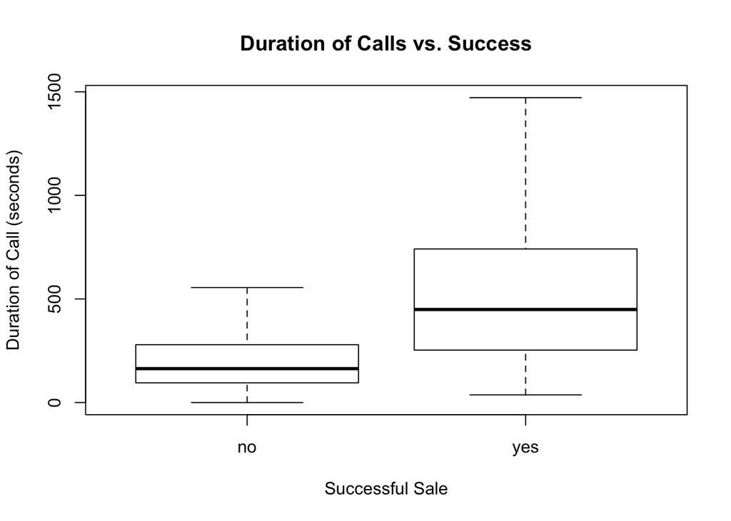

```r
boxplot(duration~y,data=tele, main="Duration of Calls vs. Success",
    xlab="Successful Sale", ylab="Duration of Call (seconds)", outline=FALSE)
```

```r
#tele <- tele[-11]
```

As we can see, when a person stays on the phone longer it is more likely to be successful. This makes sense as talking for longer usually indicates interest.

Lets prepare the datset for KNN.

Lets convert the output variable to a numeric.

Need to clean factor values to only have unique levels for later creation of dummy variables.

```r
#convert output to numeric
tele$y <- as.numeric(tele$y)
levels(tele$housing) <- c("housing_no","housing_unknown","housing_yes")
levels(tele$loan) <- c("loan_no","loan_unknown","loan_yes")
levels(tele$default) <- c("default_no","default_unknown","default_yes")


levels(tele$job)[match("unknown", levels(tele$job))] <- "job_unknown"
levels(tele$job)
```

```
##  [1] "admin."        "blue-collar"   "entrepreneur"  "housemaid"
##  [5] "management"    "retired"       "self-employed" "services"
##  [9] "student"       "technician"    "unemployed"    "job_unknown"
```

Convert Factor Variable to dummy variables. We create a for loop that goes through each factor and converts them to dummy variables. We also keep track of these variables and then drop them after.

```r
drops <- c("duration", "pdays")
for (col in names(tele)){
  if(class(tele[[col]]) == "factor" && col != "y"){
      tele <- cbind(tele, dummy(tele[[col]], sep = "_"))
      drops <- c(drops, col)
  }
}

tele <- tele[ , !(names(tele) %in% drops)]
#df1 <- cbind(tele, dummy(tele$contact, sep = "_"))
#str(tele)
```

Lets split the data into training and testing datasets. Lets do a 25/75 split

Choose k = sqrt(dataset size ) = 203

```r
#drop y from our training data
tele_n <- tele[ , !(names(tele) %in% c("y"))]

#scale using z score
tele_n <- as.data.frame(scale(tele_n))


#create training data and testing data subset
tele_train <- tele_n[10297:41188, ]
tele_test <- tele_n[1:10297, ]

#create labels
tele_train_labels <- tele[10297:41188, 20 ]
tele_test_labels <- tele[1:10297, 20 ]



#create prediction, with k ~ sqrt(41k) = 203
tele_test_pred <- knn(train = tele_train, test = tele_test,
                      cl = tele_train_labels, k=203)
#cross
CrossTable(x = tele_test_labels, y = tele_test_pred,
           prop.chisq=FALSE)
```

```
##
##
##    Cell Contents
## |-------------------------|
## |                       N |
## |           N / Row Total |
## |           N / Col Total |
## |         N / Table Total |
## |-------------------------|
##
##
## Total Observations in Table:  10297
##
##
##                  | tele_test_pred
## tele_test_labels |         0 |         1 | Row Total |
## -----------------|-----------|-----------|-----------|
##                0 |     10057 |         0 |     10057 |
##                  |     1.000 |     0.000 |     0.977 |
##                  |     0.999 |     0.000 |           |
##                  |     0.977 |     0.000 |           |
## -----------------|-----------|-----------|-----------|
##                1 |        11 |       229 |       240 |
##                  |     0.046 |     0.954 |     0.023 |
##                  |     0.001 |     1.000 |           |
##                  |     0.001 |     0.022 |           |
## -----------------|-----------|-----------|-----------|
##     Column Total |     10068 |       229 |     10297 |
##                  |     0.978 |     0.022 |           |
## -----------------|-----------|-----------|-----------|
##
##
```

Analysis:

Want to minimize false negatives. Our prediction defaults to “not going to buy”, therefore we do not want any opportunity lost.

We find in our Cross table that we have minimized the amount of false positives. We find that that our accuracy is 99.89%.